# Monitoreo Espacio-Temporal de la variación de los Glaciares Maladeta y Monte Perdido (Pirineos, España): Una Perspectiva Geomática

### **Analizamos la FAS y FAP de la serie original**

Este paso es primordial para escoger el modelo. Se ha realizado la autocorrelación simple y parcial a la serie original (sin diferencias)

En todas las funciones de autocorrelaciones se han elegido 54 lags o retardos ya que tenemos 216 datos y escogiendo ¼ del número de datos como número de retardos

[figure not shown]

```r
layout(1:2)
acf(temperatura_ts, lag.max=54, ylab="Autocorrelaciones", xlab="Retardos", main="FAS de la serie orginal")
pacf(temperatura_ts, lag.max=54, ylab="Autocorrelaciones", xlab="Retardos", main="FAP de la serie orginal")
```

**Función de Autocorrelación (FAS)**

El eje Y (Autocorrelaciones) representa los valores de autocorrelación para diferentes retardos (lags), mientras que el eje X (Retardos) representa los diferentes retardos (lags) en la serie temporal

Si las barras están dentro de los límites punteados, las autocorrelaciones no son significativamente diferentes de cero.

Podemos decir que decrece lentamente en los primeros retardos y oscila, tiene una forma ondulatoria por lo que no es un proceso ergódico

La disminución gradual de las barras sugiere que la serie tiene memoria, es decir, los valores futuros están correlacionados con los valores pasados, pero esta correlación disminuye con el tiempo.

**Función de Autocorrelación Parcial (FAP)**

El eje Y (Autocorrelaciones) representa los valores de autocorrelación parcial para diferentes retardos.Mientras que el eje X (Retardos) representa los diferentes retardos en la serie temporal.

**Número de diferencias**

El número de diferencias es utilizado para hacer que nuestra serie sea estacionaria, es decir, que no tenga tendencia ni estacionalidad. La presencia de una tendencia y estacionalidad está clara por lo que deberíamos hacer una diferencia regular y una estacional

El test de Dickey-Fuller Aumentado (ADF, por sus siglas en inglés) es una prueba estadística utilizada en análisis de series temporales para determinar si una serie temporal es estacionaria o no. La estacionaridad de una serie temporal es crucial porque muchas técnicas de modelado, como el ARIMA, requieren que las series temporales sean estacionarias para producir resultados válidos.

Raíz Unitaria: El ADF test se centra en verificar la presencia de una raíz unitaria en una serie temporal. Si una serie tiene una raíz unitaria, es no estacionaria, lo que significa que sus propiedades estadísticas (como la media y la varianza) cambian con el tiempo.

Modelo Autorregresivo (AR): El test de Dickey-Fuller básico se basa en un modelo autorregresivo de primer orden. La versión mejorada (ADF) extiende esto para considerar posibles autocorrelaciones de mayor orden en los errores del modelo.

Para este estudio se hará la prueba con el test de Dickey-Fuller y la función ndiffs.

```r
dif_prueba=ndiffs(temperatura_ts)
dif_prueba
```

```
[1] 0
```

Esta función nos indica que la serie no necesita ninguna diferencia.

```r
dif_DF=ndiffs(temperatura_ts, test = c("adf"))
dif_DF
```

```
[1] 0
```

También nos indica que no necesita ninguna diferencia

Ya que ambos tests nos indican que no hace falta diferencia en esta serie, pasamos el test de Dickey-Fuller, esta vez para que nos indique si nuestra serie es estacionaria, que es lo que buscamos

```r
adf.test(temperatura_ts, alternative = c("s"), k = 1)
```

```
    Augmented Dickey-Fuller Test

data:  temperatura_ts
Dickey-Fuller = -11.319, Lag order = 1, p-value = 0.01
alternative hypothesis: stationary
```

Hipótesis Nula (H0): La serie tiene una raíz unitaria (no estacionaria).

Hipótesis Alternativa (H1): La serie no tiene una raíz unitaria (es estacionaria).

Dado que el p-value es 0.01, lo que es menor que un nivel de significancia común de 0.05, se rechaza la hipótesis nula. Esto significa que hay suficiente evidencia estadística para concluir que la serie temporal de temperaturas es estacionaria.

Esto implica que las propiedades estadísticas de la serie (como la media y la varianza) se mantienen constantes en el tiempo, lo que es importante para modelar y predecir con métodos que requieren estacionariedad, como los modelos ARIMA.

A pesar de que el test nos indique que no necesita diferencias y que es una serie estacionaria, se ha visto que tiene estacionalidad y se puede ver como tiene tendencia (no muy marcada pero se intuye). Por tanto, se va a realizar al menos una diferencia regular y otra estacional

**Diferencia regular (quitar la tendencia)**

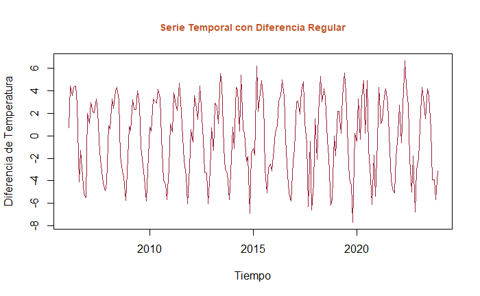

```r
# Aplicar diferenciación estacional
temperaturas_diff_regular <- diff(temperatura_ts)

# Representar la serie diferenciada estacionalmente
plot(temperaturas_diff_regular, main = "Serie Temporal con Diferencia Regular", ylab = "Diferencia de Temperatura", xlab = "Tiempo",cex.main = 0.9, col="#992339",  col.main = "#c15628")
```

Una vez realizada la diferencia regular, analizamos la FAS y FAP de la serie diferenciada regularmente

[figure not shown]

```r
layout(1:2)
acf(temperaturas_diff_regular, lag.max=54, ylab="Autocorrelaciones", xlab="Retardos", main="FAS de la serie con diferencia regular")
pacf(temperaturas_diff_regular, lag.max=54, ylab="Autocorrelaciones", xlab="Retardos", main="FAP de la serie con diferencia regular")
```

La FAS y la FAP son muy parecidas a la original lo que no nos dice mucho. Se podría probar un AR(1) en la parte regular y un MA(2) en la parte regular o incluso un MA(1)